# Loan_BY_2021_2022

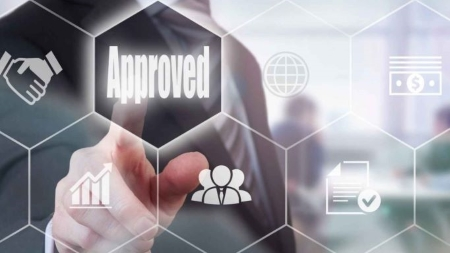

**This notebook is contains information on the volume of loans issued to legal entities.**

Source: Statistical Bulletin / Loans by type of economic activity of the country's national bank. Time period: 2021 and 11 months of 2022.

1. Total monthly indicators:

- Dynamics of the volume of loans issued by banks to legal entities in national currency (BYN), US dollars (USD), euro (EUR), Russian rubles (RUB): Total loans issued
- Total overdue debt on loans issued by banks to legal entities in national and foreign currencies (BYN): Arrears on loans
- Average interest rates on new loans issued by banks to legal entities in national currency (BYN), US dollars (USD), euro (EUR), Russian rubles (RUB): total

2. Monthly information on certain types of economic activity:

- Agriculture, forestry and fisheries
- Mining industry
- Manufacturing industry
- Supply of electricity, gas, steam, hot water and air conditioning
- Water supply; collection, treatment and disposal of waste, activities for the elimination of pollution
- Building
- Wholesale and retail trade; car and motorcycle repair - Transport activities, warehousing, postal and courier activities
- Temporary accommodation and food services
- Information and communication
- Financial and insurance activities
- Operations with real estate
- Professional, scientific and technical activities
- Activities in the field of administrative and support services
- Public administration
- Education
- Health and social services
- Creativity, sports, entertainment and recreation
- Provision of other types of services
- Activities of private households
- Activities of extraterritorial organizations and bodies

___________________________________________________________________________

Tasks: Analyze the volume of lending to legal entities, interest rates on loans and debts. Find dependencies and anomalies.

# **1 | Data Preprocessing**

- **Importing the necessary libraries**
- **Processing the dataset**

```python
from IPython.display import IFrame
import datetime
print("Notebook was last executed on:", datetime.date.today().strftime("%Y-%b-%d"))
```

```
Notebook was last executed on: 2023-Mar-03
```

```python
import os
```

```python
os.chdir('d:\TableauData\Data_upiter')
# cwd = os.getcwd()
# cwd
```

```python
os.listdir('.')
```

```
['data1.csv',
 'kurs_2021_2022.xlsx',
 'loan_start2.jpg',
 'stat_bulletin_credits_2021-2022_SET.xlsx',
 'total_pivot_tableau.xlsx',
 'total_set_eda.xlsx',
 'types_pivot_tableau.xlsx']
```

**1.1 |** Importing the libraries

- **Here we import the necessary libraries**

```python
import pandas as pd
import numpy as np
import matplotlib.pyplot as plt
import seaborn as sns
%matplotlib inline

!pip install wordcloud
from wordcloud import WordCloud, STOPWORDS
```

**1.2 |** Importing the dataset

- **Collect the dataframe from the sheets of the Excel file**

```python
file = 'stat_bulletin_credits_2021-2022_SET.xlsx'
```

```python
xl = pd.ExcelFile(file)
```

```python
sheet_names = xl.sheet_names
sheet_names
```

```
['Vol_BYN_dynamics',
 'Vol_USD_dynamics',
 'Vol_EUR_dynamics',
 'Vol_RUR_dynamics',
 'Total_Vol_BYN_equivalent_dyn',
 'Debt_BYN_equivalent_dynamics',
 'AV_%_BYN',
 'AV_%_USD',
 'AV_%_EUR',
 'AV_%_RUR']
```

```python
# df = pd.DataFrame()
# for sheet in sheet_names:
#     tmp = xl.parse(sheet, header=3, index_col=None)
#     df = pd.concat([df, tmp], ignore_index=False, axis=1, join='outer', verify_integrity = False , sort = False)

# df
```

```python
df = xl.parse(sheet_name=sheet_names[0], header=3, na_values=None)

for sheet in sheet_names[1:]:
    tmp = xl.parse(sheet, header=3)
    df = df.merge(tmp, how ='outer', on = ['Indicators', ' Years'])
```

```python
print('Shape of the training dataset:')
print('There are {} rows and {} columns in train dataset.'.format(df.shape[0], df.shape[1]))
```

```
Shape of the training dataset:
There are 48 rows and 122 columns in train dataset.
```

```python
df.columns.tolist()
```

```
['Indicators',
 ' Years',
 'BYN_million_january',
 'BYN_million_january -february',
 'BYN_million_january -march',
 'BYN_million_january -april',
 'BYN_million_january -may',
 'BYN_million_january -june',
 'BYN_million_january -july',
 'BYN_million_january -august',
 'BYN_million_january -september',
 'BYN_million_january -оctober',
 'BYN_million_january -november',
 'BYN_million_january -december',
 'USD_million_january',
 'USD_million_january -february',
 'USD_million_january -march',
 'USD_million_january -april',
 'USD_million_january -may',
 'USD_million_january -june',
 'USD_million_january -july',
 'USD_million_january -august',
 'USD_million_january -september',
 'USD_million_january -оctober',
 'USD_million_january -november',
 'USD_million_january -december',
 'EUR_million_january',
 'EUR_million_january -february',
 'EUR_million_january -march',
 'EUR_million_january -april',
 'EUR_million_january -may',
 'EUR_million_january -june',
 'EUR_million_january -july',
 'EUR_million_january -august',
 'EUR_million_january -september',
 'EUR_million_january -оctober',
 'EUR_million_january -november',
 'EUR_million_january -december',
 'RUB_million_january',
 'RUB_million_january -february',
```

[output cut: 67 more lines]

```
 '%_EUR_оctober',
 '%_EUR_november',
 '%_EUR_december',
 '%_RUB_january',
 '%_RUB_february',
 '%_RUB_march',
 '%_RUB_april',
 '%_RUB_may',
 '%_RUB_june',
 '%_RUB_july',
 '%_RUB_august',
 '%_RUB_september',
 '%_RUB_оctober',
 '%_RUB_november',
 '%_RUB_december']
```

```python
# df.to_excel('./total_set_eda.xlsx')
```

# **2 | Exploratory data analysis**

**2.1 |** Dataset Formatting

- **Format column names and convert values to number**

```python
''' Rename all columns'''

df = df.rename(columns=lambda col: col.replace('%', 'per').replace(' ', '').replace('BY_equivalent_01.', '').replace('Vol_', '') \
                .replace('million_', '').strip('.').replace('RUR', 'RUB') \
                .replace('01', 'january').replace('02', 'february').replace('03', 'march') \
                .replace('04', 'april').replace('05', 'may').replace('06', 'june') \
                .replace('07', 'july').replace('08', 'august').replace('09', 'september') \
                .replace('10', 'оctober').replace('11', 'november').replace('12', 'december'))
```

```python
''' Create a new column <indicators_id> based on the changed names from <Indicators>'''

df['indicators_id'] = df.Indicators.apply(lambda x: x.split(',', 1)[0].split('of ', 1)[-1].split(';', 1)[0].lower().replace(' ', '_'))
```

```python
df.info()
```

```
<class 'pandas.core.frame.DataFrame'>
Int64Index: 48 entries, 0 to 47
Columns: 123 entries, Indicators to indicators_id
dtypes: int64(1), object(122)
memory usage: 46.5+ KB
```

```python
df.dtypes
```

```
Indicators              object
Years                    int64
BYN_january             object
BYN_january-february    object
BYN_january-march       object
                         ...
per_RUB_september       object
per_RUB_оctober         object
per_RUB_november        object
per_RUB_december        object
indicators_id           object
Length: 123, dtype: object
```

```python
df.head(3)
```

|  | Indicators | Years | BYN_january | BYN_january-february | BYN_january-march | BYN_january-april | BYN_january-may | BYN_january-june | BYN_january-july | BYN_january-august | ... | per_RUB_april | per_RUB_may | per_RUB_june | per_RUB_july | per_RUB_august | per_RUB_september | per_RUB_оctober | per_RUB_november | per_RUB_december | indicators_id |
| --- | --- | --- | --- | --- | --- | --- | --- | --- | --- | --- | --- | --- | --- | --- | --- | --- | --- | --- | --- | --- | --- |
| 0 | Total loans issued | 2021 | 2 657,0 | 5 357,6 | 8 881,3 | 12 497,8 | 15 837,0 | 19 422,2 | 23 318,8 | 27 267,5 | ... | NaN | NaN | NaN | NaN | NaN | NaN | NaN | NaN | NaN | total_loans_issued |
| 1 | Total loans issued | 2022 | 4 483,7 | 8 889,1 | 13 105,2 | 17 819,7 | 22 066,9 | 26 635,0 | 32 357,4 | 38 673,9 | ... | NaN | NaN | NaN | NaN | NaN | NaN | NaN | NaN | NaN | total_loans_issued |
| 2 | Agriculture, forestry and fisheries | 2021 | 81,5 | 208,6 | 451,4 | 642,6 | 749,4 | 877,5 | 1 006,3 | 1 172,2 | ... | 12,11 | 10,06 | 10,10 | 11,20 | 13,03 | 11,81 | 11,81 | 11,15 | 11,91 | agriculture |

3 rows × 123 columns

```python
def convert(val):
    """
     Converts a string value to a floating point number:
     - removes spaces
     - replaces ',' with '.'
     - converts to floating point number
    """
    if val is np.nan:
        pass
    else:
        new_val = val.replace(' ', '').replace(',', '.')
        return float(new_val)
```

```python
"""
 Loop to convert all values from text to number in specified column range
"""
for col in df.columns[2:-1]:
    df[col] = df[col].apply(convert)
```

```python
# df.to_excel('./total_set_eda.xlsx')
```

```python
# !pip install phik
# import phik
# from phik.report import plot_correlation_matrix
# from phik import report

# phik_overview = df.phik_matrix()
# phik_overview
```

```python
df_copy = df.copy(deep=True)
df.head(3)
```

|  | Indicators | Years | BYN_january | BYN_january-february | BYN_january-march | BYN_january-april | BYN_january-may | BYN_january-june | BYN_january-july | BYN_january-august | ... | per_RUB_april | per_RUB_may | per_RUB_june | per_RUB_july | per_RUB_august | per_RUB_september | per_RUB_оctober | per_RUB_november | per_RUB_december | indicators_id |
| --- | --- | --- | --- | --- | --- | --- | --- | --- | --- | --- | --- | --- | --- | --- | --- | --- | --- | --- | --- | --- | --- |
| 0 | Total loans issued | 2021 | 2657.0 | 5357.6 | 8881.3 | 12497.8 | 15837.0 | 19422.2 | 23318.8 | 27267.5 | ... | NaN | NaN | NaN | NaN | NaN | NaN | NaN | NaN | NaN | total_loans_issued |
| 1 | Total loans issued | 2022 | 4483.7 | 8889.1 | 13105.2 | 17819.7 | 22066.9 | 26635.0 | 32357.4 | 38673.9 | ... | NaN | NaN | NaN | NaN | NaN | NaN | NaN | NaN | NaN | total_loans_issued |
| 2 | Agriculture, forestry and fisheries | 2021 | 81.5 | 208.6 | 451.4 | 642.6 | 749.4 | 877.5 | 1006.3 | 1172.2 | ... | 12.11 | 10.06 | 10.1 | 11.2 | 13.03 | 11.81 | 11.81 | 11.15 | 11.91 | agriculture |

3 rows × 123 columns

```python
df.info()
```

```
<class 'pandas.core.frame.DataFrame'>
Int64Index: 48 entries, 0 to 47
Columns: 123 entries, Indicators to indicators_id
dtypes: float64(120), int64(1), object(2)
memory usage: 46.5+ KB
```

**2.2 |** Split the table in two

- **One will represent the general indicators**
- **Second in line of business**

```python
df_types = df.set_index('indicators_id')
```

```python
total = ['total', 'arrears_on_loans', 'total_loans_issued']
df_toval = df_types.query('indicators_id == @total').reset_index()
```

```python
df_types.drop(labels=['total', 'arrears_on_loans', 'total_loans_issued'], axis=0, inplace=True)
df_types.reset_index(inplace=True)
```

```python
df_types.head()
```

|  | indicators_id | Indicators | Years | BYN_january | BYN_january-february | BYN_january-march | BYN_january-april | BYN_january-may | BYN_january-june | BYN_january-july | ... | per_RUB_march | per_RUB_april | per_RUB_may | per_RUB_june | per_RUB_july | per_RUB_august | per_RUB_september | per_RUB_оctober | per_RUB_november | per_RUB_december |
| --- | --- | --- | --- | --- | --- | --- | --- | --- | --- | --- | --- | --- | --- | --- | --- | --- | --- | --- | --- | --- | --- |
| 0 | agriculture | Agriculture, forestry and fisheries | 2021 | 81.5 | 208.6 | 451.4 | 642.6 | 749.4 | 877.5 | 1006.3 | ... | 11.55 | 12.11 | 10.06 | 10.10 | 11.20 | 13.03 | 11.81 | 11.81 | 11.15 | 11.91 |
| 1 | agriculture | Agriculture, forestry and fisheries | 2022 | 110.6 | 231.3 | 404.8 | 542.2 | 697.3 | 869.7 | 1017.1 | ... | 27.84 | 22.44 | 21.44 | 19.74 | 18.53 | 18.63 | 11.96 | 16.86 | 16.43 | NaN |
| 2 | мining_industry | Мining industry | 2021 | 0.6 | 1.0 | 1.6 | 2.6 | 4.2 | 4.9 | 35.6 | ... | NaN | NaN | NaN | NaN | NaN | NaN | NaN | NaN | NaN | NaN |
| 3 | мining_industry | Мining industry | 2022 | 2.2 | 3.5 | 92.1 | 106.0 | 180.1 | 252.6 | 325.4 | ... | NaN | NaN | NaN | 18.89 | NaN | NaN | NaN | NaN | NaN | NaN |
| 4 | manufacturing_industry | Manufacturing industry | 2021 | 742.7 | 1539.4 | 2592.4 | 3687.0 | 4601.0 | 5671.5 | 6944.1 | ... | 9.80 | 10.10 | 10.13 | 10.12 | 10.08 | 11.10 | 11.03 | 11.72 | 11.07 | 11.06 |

5 rows × 123 columns

```python
df_toval
```

|  | indicators_id | Indicators | Years | BYN_january | BYN_january-february | BYN_january-march | BYN_january-april | BYN_january-may | BYN_january-june | BYN_january-july | ... | per_RUB_march | per_RUB_april | per_RUB_may | per_RUB_june | per_RUB_july | per_RUB_august | per_RUB_september | per_RUB_оctober | per_RUB_november | per_RUB_december |
| --- | --- | --- | --- | --- | --- | --- | --- | --- | --- | --- | --- | --- | --- | --- | --- | --- | --- | --- | --- | --- | --- |
| 0 | total_loans_issued | Total loans issued | 2021 | 2657.0 | 5357.6 | 8881.3 | 12497.8 | 15837.0 | 19422.2 | 23318.8 | ... | NaN | NaN | NaN | NaN | NaN | NaN | NaN | NaN | NaN | NaN |
| 1 | total_loans_issued | Total loans issued | 2022 | 4483.7 | 8889.1 | 13105.2 | 17819.7 | 22066.9 | 26635.0 | 32357.4 | ... | NaN | NaN | NaN | NaN | NaN | NaN | NaN | NaN | NaN | NaN |
| 2 | arrears_on_loans | Arrears on loans | 2021 | NaN | NaN | NaN | NaN | NaN | NaN | NaN | ... | NaN | NaN | NaN | NaN | NaN | NaN | NaN | NaN | NaN | NaN |
| 3 | arrears_on_loans | Arrears on loans | 2022 | NaN | NaN | NaN | NaN | NaN | NaN | NaN | ... | NaN | NaN | NaN | NaN | NaN | NaN | NaN | NaN | NaN | NaN |
| 4 | total | Total | 2021 | NaN | NaN | NaN | NaN | NaN | NaN | NaN | ... | 9.52 | 9.51 | 9.89 | 10.02 | 10.36 | 11.18 | 11.09 | 11.81 | 11.35 | 11.42 |
| 5 | total | Total | 2022 | NaN | NaN | NaN | NaN | NaN | NaN | NaN | ... | 26.08 | 24.37 | 21.04 | 17.82 | 16.81 | 16.28 | 14.77 | 13.60 | 12.69 | NaN |

6 rows × 123 columns

- **Divide the common table by individual indicators**
- **Let's calculate the monthly volume of loans issued, since the data comes with a cumulative total.**

```python
'''  Function for slicing our table and calculate the monthly volume for total indicators '''

def cut_table(df, start, indicators_id=None):
    stop = start+12
    if indicators_id == 'total_loans_issued':
        table=df[df.indicators_id == indicators_id] \
                            .dropna(axis = 1, how='all') \
                            .reset_index() \
                            .iloc[:, start:stop]
        table_ = table.shift(1, axis=1) \
                            .fillna(0, limit=2)
        table = table.subtract(table_, axis=1)
        table = table.rename(columns=lambda col: col.replace('january-', ''))
        table.insert(0, 'Years', [2021, 2022])
        return table

    elif indicators_id == 'arrears_on_loans' or indicators_id == 'total':
        table=df[df.indicators_id == indicators_id] \
                            .dropna(axis = 1, how='all') \
                            .reset_index() \
                            .iloc[:, start:stop]
        table.insert(0, 'Years', [2021, 2022])
        return table

    else:
        table=df \
                            .dropna(axis = 1, how='all') \
                            .reset_index() \
                            .iloc[:, start:stop]
        ser = pd.Series([int()])
        for x in range(len(df)):
            if x%2==0:
                ser[x]=2021
            else:
                ser[x]=2022
        table.insert(0, 'Years', ser)
        table.insert(0, 'Indicators', df['Indicators'])
        table.insert(0, 'indicators_id', df['indicators_id'])
        return table
#     raise
#         print(f"Indicators_id <{indicators_id}> not available in table")
```

```python
'''  Creating a dictionary of future table names and slicing index '''

dict_future_tables = {'Name of dataframe': 'start_index', 'df_total_loans_issued_BYN': 4, 'df_total_loans_issued_USD': 16,
                             'df_total_loans_issued_EUR': 28, 'df_total_loans_issued_RUB': 40,
                             'df_total_loans_issued_EQ': 52, 'df_arrears_on_loans': 4,  'df_percent_BYN': 4,
                             'df_percent_USD': 16, 'df_percent_EUR': 28, 'df_percent_RUB': 40}
dict_future_tables
```

```
{'Name of dataframe': 'start_index',
 'df_total_loans_issued_BYN': 4,
 'df_total_loans_issued_USD': 16,
 'df_total_loans_issued_EUR': 28,
 'df_total_loans_issued_RUB': 40,
 'df_total_loans_issued_EQ': 52,
 'df_arrears_on_loans': 4,
 'df_percent_BYN': 4,
 'df_percent_USD': 16,
 'df_percent_EUR': 28,
 'df_percent_RUB': 40}
```

```python
# list_of_index = pd.DataFrame({'index': ['start'], 'df_total_loans_issued_BYN': [4], 'df_total_loans_issued_USD': [16],
#                              'df_total_loans_issued_EUR': [28], 'df_total_loans_issued_RUB': [40],
#                              'df_total_loans_issued_EQ': [52], 'df_arrears_on_loans': [4],  'df_percent_BYN': [4],
#                              'df_percent_USD': [16], 'df_percent_EUR': [28], 'df_percent_EUR': [40]})
# list_of_index
```

- **Created local tables by common parameters**

```python
df_total_loans_issued_BYN = cut_table(df_toval, 4, 'total_loans_issued')
df_total_loans_issued_USD = cut_table(df_toval, 16, 'total_loans_issued')
df_total_loans_issued_EUR = cut_table(df_toval, 28, 'total_loans_issued')
df_total_loans_issued_RUB = cut_table(df_toval, 40, 'total_loans_issued')
df_total_loans_issued_EQ = cut_table(df_toval, 52, 'total_loans_issued')
df_arrears_on_loans = cut_table(df_toval, 4, 'arrears_on_loans')
df_percent_BYN = cut_table(df_toval, 4, 'total')
df_percent_USD = cut_table(df_toval, 16, 'total')
df_percent_EUR = cut_table(df_toval, 28, 'total')
df_percent_RUB = cut_table(df_toval, 40, 'total')
```

# **3 | Visualization and data analysis**

**3.1 |** Total loans issued in national and foreign currencies at the rate of BYN

- **Total loans issued in national and foreign currencies at the rate of BYN in 2021 and 2022 years**

```python
title = f"Total loans issued in national and foreign currencies at the exchange rate: \nfor 2021 by {round(df_total_loans_issued_EQ.iloc[0, 1:].sum(), 2)} млн \nfor 11 months of 2022 by {round(df_total_loans_issued_EQ.iloc[1, 1:].sum(), 2)} млн"
print(title)
fig_title = 'Total loans issued in national \nand foreign currencies at the rate of: \nfor 2021 by 92713.0 mln \nfor 11 months of 2022 by 90568.9 mln'
df_total_loans_issued_EQ
```

```
Total loans issued in national and foreign currencies at the exchange rate:
for 2021 by 92713.0 млн
for 11 months of 2022 by 90568.9 млн
```

|  | Years | Total_january | Total_february | Total_march | Total_april | Total_may | Total_june | Total_july | Total_august | Total_september | Total_оctober | Total_november | Total_december |
| --- | --- | --- | --- | --- | --- | --- | --- | --- | --- | --- | --- | --- | --- |
| 0 | 2021 | 6187.5 | 5548.4 | 7367.5 | 7959.1 | 6921.3 | 7344.6 | 7773.2 | 7297.2 | 8018.8 | 8971.7 | 8646.6 | 10677.1 |
| 1 | 2022 | 8684.1 | 8704.7 | 6740.9 | 7830.4 | 6327.0 | 7590.1 | 8747.7 | 8489.9 | 8862.0 | 9586.8 | 9005.3 | NaN |

- **Visualization of the dynamics of loans issued in general**

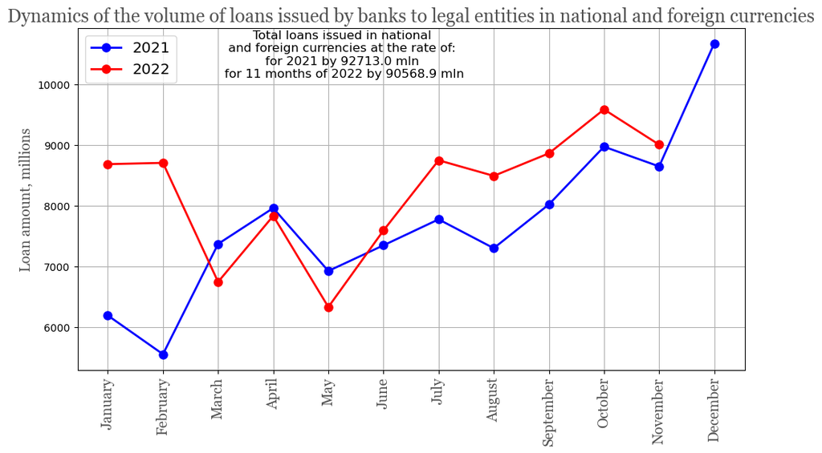

```python
'''  General font and color settings '''
plt.style.use('default')
font_color = '#525252'
csfont = {'fontname':'Georgia'} # title font
hfont = {'fontname':'Calibri'} # main font
colors = ['#FFA07A', '#5F9EA0', '#DA70D6', '#66CDAA']

# Plotting
fig, ax = plt.subplots()
plt.subplots_adjust(left=1, right=2, top=None, bottom=None)
fig.suptitle(fig_title, x=1.4, y=0.82, ha='center', va='center')
fig.set_figwidth(9)
fig.set_figheight(6)
df_total_loans_issued_EQ.iloc[0, 1:].plot(y="Years", marker='o', linewidth=2, markersize=8, label='2021', c='blue')
df_total_loans_issued_EQ.iloc[1, 1:].plot(y="Years", marker='o', linewidth=2, markersize=8, label='2022', c='red')

plt.legend(loc=2, fontsize='x-large')

plt.title('Dynamics of the volume of loans issued by banks to legal entities in national and foreign currencies', fontsize=18, color=font_color, **csfont)


# plt.xlabel('Months')
plt.ylabel('Loan amount, millions', fontsize=14, color=font_color, **csfont)
ax.grid()
labels = ['January', 'February', 'March', 'April', 'May', 'June', 'July', 'August', 'September', 'October', 'November', 'December']
plt.xticks(np.arange(12), labels, color=font_color, **csfont)
ax.xaxis.set_tick_params(rotation=90, labelsize=14)
```

**Conclusions on the monthly volume of loans issued total, millions:**

1. In 2021, January (6187.5) and February (5548.4) had the lowest lending volumes. Further, throughout March - September, lending was from 7000 to 8000. The peak was reached in December and amounted to 10677.1 or 92% more than in February.

2. The year 2022 in January and February was marked by lending in the amount of 8700. In March, there was a sharp decrease in lending volumes by 9% from March 2021 and 22.5% below February 2022. In May, the lowest lending was noted - 6327 million. Then lending volumes increased. The maximum lending for 11 months was noted in October (9586.8).

**3.2 |** Analyze the data in the context of BYN, USD, EUR, RUB

- **General parameters of loans issued by individual currencies**

```python
print("\nGeneral parameters of loans issued in BYN per month, million:")
print(f"Minimum value in 2021 >>> {round(df_total_loans_issued_BYN.iloc[0, 1:].min(), 1)}, in 2022 >>> {round(df_total_loans_issued_BYN.iloc[1, 1:].min(), 1)}")
print(f"Maximum value in 2021 >>> {round(df_total_loans_issued_BYN.iloc[0, 1:].max(), 1)}, in 2022 >>> {round(df_total_loans_issued_BYN.iloc[1, 1:].max(), 1)}")
print(f"The amount of loans issued in 2021 >>> {round(df_total_loans_issued_BYN.iloc[0, 1:].sum(), 2)}, for 11 months in 2022 >>> {round(df_total_loans_issued_BYN.iloc[1, 1:].sum(), 2)}")


print("\nGeneral parameters of loans issued in RUB per month, million:")
print(f"Minimum value in 2021 >>> {round(df_total_loans_issued_RUB.iloc[0, 1:].min(), 1)}, in 2022 >>> {round(df_total_loans_issued_RUB.iloc[1, 1:].min(), 1)}")
print(f"Maximum value in 2021 >>> {round(df_total_loans_issued_RUB.iloc[0, 1:].max(), 1)}, in 2022 >>> {round(df_total_loans_issued_RUB.iloc[1, 1:].max(), 1)}")
print(f"The amount of loans issued in 2021 >>> {round(df_total_loans_issued_RUB.iloc[0, 1:].sum(), 2)}, for 11 months in 2022 >>> {round(df_total_loans_issued_RUB.iloc[1, 1:].sum(), 2)}")

print("\nGeneral parameters of loans issued in USD per month, million:")
print(f"Minimum value in 2021 >>> {round(df_total_loans_issued_USD.iloc[0, 1:].min(), 1)}, in 2022 >>> {round(df_total_loans_issued_USD.iloc[1, 1:].min(), 1)}")
print(f"Maximum value in 2021 >>> {round(df_total_loans_issued_USD.iloc[0, 1:].max(), 1)}, in 2022 >>> {round(df_total_loans_issued_USD.iloc[1, 1:].max(), 1)}")
print(f"The amount of loans issued in 2021 >>> {round(df_total_loans_issued_USD.iloc[0, 1:].sum(), 2)}, for 11 months in 2022 >>> {round(df_total_loans_issued_USD.iloc[1, 1:].sum(), 2)}")

print("\nGeneral parameters of loans issued in USD per month, million:")
print(f"Minimum value in 2021 >>> {round(df_total_loans_issued_EUR.iloc[0, 1:].min(), 1)}, in 2022 >>> {round(df_total_loans_issued_EUR.iloc[1, 1:].min(), 1)}")
print(f"Maximum value in 2021 >>> {round(df_total_loans_issued_EUR.iloc[0, 1:].max(), 1)}, in 2022 >>> {round(df_total_loans_issued_EUR.iloc[1, 1:].max(), 1)}")
print(f"he amount of loans issued in 2021 >>> {round(df_total_loans_issued_EUR.iloc[0, 1:].sum(), 2)}, for 11 months in 2022 >>> {round(df_total_loans_issued_EUR.iloc[1, 1:].sum(), 2)}")
```

```
General parameters of loans issued in BYN per month, million:
Minimum value in 2021 >>> 2657.0, in 2022 >>> 4216.1
Maximum value in 2021 >>> 5366.3, in 2022 >>> 7135.6
The amount of loans issued in 2021 >>> 45926.3, for 11 months in 2022 >>> 59437.2

General parameters of loans issued in RUB per month, million:
Minimum value in 2021 >>> 17852.4, in 2022 >>> 17778.2
Maximum value in 2021 >>> 27375.6, in 2022 >>> 64333.9
The amount of loans issued in 2021 >>> 272328.1, for 11 months in 2022 >>> 435467.9

General parameters of loans issued in USD per month, million:
Minimum value in 2021 >>> 399.9, in 2022 >>> 107.4
Maximum value in 2021 >>> 707.3, in 2022 >>> 439.2
The amount of loans issued in 2021 >>> 6083.0, for 11 months in 2022 >>> 2359.3

General parameters of loans issued in USD per month, million:
Minimum value in 2021 >>> 361.7, in 2022 >>> 80.6
Maximum value in 2021 >>> 1038.7, in 2022 >>> 878.1
he amount of loans issued in 2021 >>> 7356.6, for 11 months in 2022 >>> 2737.5
```

```python
df_total_loans_issued_BYN
```

|  | Years | BYN_january | BYN_february | BYN_march | BYN_april | BYN_may | BYN_june | BYN_july | BYN_august | BYN_september | BYN_оctober | BYN_november | BYN_december |
| --- | --- | --- | --- | --- | --- | --- | --- | --- | --- | --- | --- | --- | --- |
| 0 | 2021 | 2657.0 | 2700.6 | 3523.7 | 3616.5 | 3339.2 | 3585.2 | 3896.6 | 3948.7 | 4475.1 | 4330.7 | 4486.7 | 5366.3 |
| 1 | 2022 | 4483.7 | 4405.4 | 4216.1 | 4714.5 | 4247.2 | 4568.1 | 5722.4 | 6316.5 | 7005.4 | 7135.6 | 6622.3 | NaN |

```python
df_total_loans_issued_RUB
```

|  | Years | RUB_january | RUB_february | RUB_march | RUB_april | RUB_may | RUB_june | RUB_july | RUB_august | RUB_september | RUB_оctober | RUB_november | RUB_december |
| --- | --- | --- | --- | --- | --- | --- | --- | --- | --- | --- | --- | --- | --- |
| 0 | 2021 | 17852.4 | 19075.4 | 22983.6 | 26569.2 | 24919.6 | 23191.5 | 27375.6 | 19021.8 | 23659.6 | 22059.7 | 22715.0 | 22904.7 |
| 1 | 2022 | 17778.2 | 18740.0 | 57840.3 | 64333.9 | 40371.2 | 48193.9 | 47934.5 | 34836.3 | 25226.8 | 43315.8 | 36897.0 | NaN |

```python
df_total_loans_issued_USD
```

|  | Years | USD_january | USD_february | USD_march | USD_april | USD_may | USD_june | USD_july | USD_august | USD_september | USD_оctober | USD_november | USD_december |
| --- | --- | --- | --- | --- | --- | --- | --- | --- | --- | --- | --- | --- | --- |
| 0 | 2021 | 404.4 | 399.9 | 512.0 | 569.1 | 444.6 | 515.7 | 484.2 | 416.4 | 425.9 | 589.7 | 707.3 | 613.8 |
| 1 | 2022 | 397.4 | 439.2 | 142.9 | 179.8 | 107.4 | 139.8 | 127.0 | 174.8 | 223.3 | 175.6 | 252.1 | NaN |

```python
df_total_loans_issued_EUR
```

|  | Years | EUR_january | EUR_february | EUR_march | EUR_april | EUR_may | EUR_june | EUR_july | EUR_august | EUR_september | EUR_оctober | EUR_november | EUR_december |
| --- | --- | --- | --- | --- | --- | --- | --- | --- | --- | --- | --- | --- | --- |
| 0 | 2021 | 597.5 | 361.7 | 547.7 | 623.5 | 522.6 | 544.8 | 568.4 | 560.0 | 564.5 | 850.6 | 576.6 | 1038.7 |
| 1 | 2022 | 878.1 | 851.5 | 85.2 | 101.9 | 80.6 | 189.7 | 204.0 | 81.0 | 81.3 | 95.3 | 88.9 | NaN |

- **Visualization of monthly volume of loans issued by banks to legal entities**

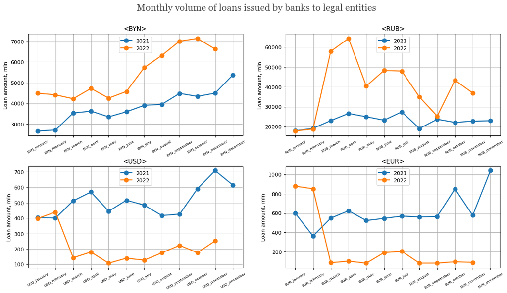

```python
fig = plt.figure(figsize=(16, 8), dpi=80)
plt.subplots_adjust(wspace=0.2, hspace=0.3)
fig.suptitle('Monthly volume of loans issued by banks to legal entities', fontsize=18, color=font_color, **csfont)
ax_1 = fig.add_subplot(2, 2, 1, title='<BYN>', ylabel='Loan amount, mln')
ax_2 = fig.add_subplot(2, 2, 3, title='<USD>', ylabel='Loan amount, mln')
ax_3 = fig.add_subplot(2, 2, 2, title='<RUB>', ylabel='Loan amount, mln')
ax_4 = fig.add_subplot(2, 2, 4, title='<EUR>', ylabel='Loan amount, mln')

ax_1.plot(df_total_loans_issued_BYN.iloc[0, 1:], marker='o', linewidth=2, markersize=8, label='2021')
ax_1.plot(df_total_loans_issued_BYN.iloc[1, 1:], marker='o', linewidth=2, markersize=8, label='2022')
ax_2.plot(df_total_loans_issued_USD.iloc[0, 1:], marker='o', linewidth=2, markersize=8, label='2021')
ax_2.plot(df_total_loans_issued_USD.iloc[1, 1:], marker='o', linewidth=2, markersize=8, label='2022')
ax_3.plot(df_total_loans_issued_RUB.iloc[0, 1:], marker='o', linewidth=2, markersize=8, label='2021')
ax_3.plot(df_total_loans_issued_RUB.iloc[1, 1:], marker='o', linewidth=2, markersize=8, label='2022')
ax_4.plot(df_total_loans_issued_EUR.iloc[0, 1:], marker='o', linewidth=2, markersize=8, label='2021')
ax_4.plot(df_total_loans_issued_EUR.iloc[1, 1:], marker='o', linewidth=2, markersize=8, label='2022')

ax_1.legend(loc=9, fontsize='medium')
ax_2.legend(loc=9, fontsize='medium')
ax_3.legend(loc=9, fontsize='medium')
ax_4.legend(loc=9, fontsize='medium')
ax_1.grid()
ax_2.grid()
ax_3.grid()
ax_4.grid()
ax_1.xaxis.set_tick_params(rotation=30, labelsize=7)
ax_2.xaxis.set_tick_params(rotation=30, labelsize=7)
ax_3.xaxis.set_tick_params(rotation=30, labelsize=7)
ax_4.xaxis.set_tick_params(rotation=30, labelsize=7)
```

**An interesting situation arises when analyzing lending data by currency:**

1. In national currency (BYN), loans issued in 2022 are significantly larger than in 2021. There is a more significant increase in the period July-October 2022.

2. In Russian rubles (RUB), lending was approximately at the same level during 2021. And in March 2022, there was a rapid jump in loans issued by 209%. The maximum value was in April - 64333.9 million. Then the volumes fell sharply. In September 2022, they equaled September 2021 by one month.

3. In US dollars (USD), lending in 2021 from January to September was in the range of 400 - 570, in November there was a peak - 707.3 million. In 2022, in March, the situation changed dramatically. There was a drop in lending to 142.9, which is 207% lower than February of the current year. Then lending was in the range from 107.4 (May) to 252.1 (November).

4. In euros (EUR) in 2021, lending was relatively stable around 600 million. However, there was a fall in February (361.7) and a sharp increase in October (850.6) and December (1038.7). The year 2022 continued with high lending volumes of approximately 860 million. However, in March there was a sharp drop to 85.2, which is 899%! from the previous month - February. From March to November, lending volumes remained steadily low in the region of 80-200 million rubles.

**It can be concluded that since March 2022 there has been a sharp change in the lending currency. There was a sharp drop in USD and EUR. However, there was a proportional increase in lending in RUB.**

- **Create a PivotTable**

```python
'''
     Function for assembling a new table through the <melt> and <right merge> methods:
        (dfs) - list of dataframe tables;
        (value_names) - list of value column names. The order in the list must match the order (dfs);
        (on_1) - 'str', connection argument, <melt> column name for *id_vars;
        (on_2) - 'str', connection argument №2, <melt> column name for *var_name;
'''

def melt_merge_right(dfs, value_names, on_1, on_2):
    iterator = iter(range(len(value_names)))
    df_out = pd.DataFrame(columns = {on_1, on_2})
    for d in dfs:
        n = next(iterator)
        d = d.rename(columns=lambda col: col.split('_')[-1]).melt(id_vars=on_1, var_name=on_2, value_name=value_names[n])
        df_out = df_out.merge(d, how='right', on=[on_1, on_2])
    return df_out
```

```python
dfs = [df_total_loans_issued_BYN, df_total_loans_issued_RUB, df_total_loans_issued_USD,
     df_total_loans_issued_EUR, df_total_loans_issued_EQ, df_arrears_on_loans,
    df_percent_BYN, df_percent_RUB, df_percent_USD, df_percent_EUR]

value_names = ['BYN', 'RUB', 'USD', 'EUR', 'EQ', 'arrears', 'per_BYN', 'per_RUB', 'per_USD', 'per_EUR']
```

```python
pivot_table = melt_merge_right(dfs, value_names, 'Years', 'month')
```

```python
pivot_table
```

|  | Years | month | BYN | RUB | USD | EUR | EQ | arrears | per_BYN | per_RUB | per_USD | per_EUR |
| --- | --- | --- | --- | --- | --- | --- | --- | --- | --- | --- | --- | --- |
| 0 | 2021 | january | 2657.0 | 17852.4 | 404.4 | 597.5 | 6187.5 | 74.8 | 11.24 | 9.57 | 4.89 | 5.49 |
| 1 | 2022 | january | 4483.7 | 17778.2 | 397.4 | 878.1 | 8684.1 | 68.9 | 13.22 | 12.13 | 6.28 | 6.63 |
| 2 | 2021 | february | 2700.6 | 19075.4 | 399.9 | 361.7 | 5548.4 | 81.9 | 11.06 | 9.73 | 5.65 | 5.91 |
| 3 | 2022 | february | 4405.4 | 18740.0 | 439.2 | 851.5 | 8704.7 | 76.5 | 12.95 | 11.62 | 6.83 | 6.62 |
| 4 | 2021 | march | 3523.7 | 22983.6 | 512.0 | 547.7 | 7367.5 | 82.5 | 11.46 | 9.52 | 5.38 | 5.55 |
| 5 | 2022 | march | 4216.1 | 57840.3 | 142.9 | 85.2 | 6740.9 | 98.0 | 18.36 | 26.08 | 8.43 | 7.31 |
| 6 | 2021 | april | 3616.5 | 26569.2 | 569.1 | 623.5 | 7959.1 | 85.3 | 12.02 | 9.51 | 5.41 | 5.43 |
| 7 | 2022 | april | 4714.5 | 64333.9 | 179.8 | 101.9 | 7830.4 | 483.6 | 19.36 | 24.37 | 8.98 | 8.89 |
| 8 | 2021 | may | 3339.2 | 24919.6 | 444.6 | 522.6 | 6921.3 | 98.1 | 12.21 | 9.89 | 5.60 | 5.54 |
| 9 | 2022 | may | 4247.2 | 40371.2 | 107.4 | 80.6 | 6327.0 | 179.7 | 19.19 | 21.04 | 8.98 | 7.95 |
| 10 | 2021 | june | 3585.2 | 23191.5 | 515.7 | 544.8 | 7344.6 | 104.7 | 12.57 | 10.02 | 5.27 | 5.77 |
| 11 | 2022 | june | 4568.1 | 48193.9 | 139.8 | 189.7 | 7590.1 | 204.5 | 18.80 | 17.82 | 10.14 | 7.63 |
| 12 | 2021 | july | 3896.6 | 27375.6 | 484.2 | 568.4 | 7773.2 | 92.3 | 12.75 | 10.36 | 5.82 | 6.18 |
| 13 | 2022 | july | 5722.4 | 47934.5 | 127.0 | 204.0 | 8747.7 | 184.9 | 16.90 | 16.81 | 9.24 | 8.19 |
| 14 | 2021 | august | 3948.7 | 19021.8 | 416.4 | 560.0 | 7297.2 | 92.7 | 13.19 | 11.18 | 6.10 | 6.35 |
| 15 | 2022 | august | 6316.5 | 34836.3 | 174.8 | 81.0 | 8489.9 | 193.5 | 14.98 | 16.28 | 9.88 | 9.04 |
| 16 | 2021 | september | 4475.1 | 23659.6 | 425.9 | 564.5 | 8018.8 | 87.6 | 13.13 | 11.09 | 6.28 | 6.32 |
| 17 | 2022 | september | 7005.4 | 25226.8 | 223.3 | 81.3 | 8862.0 | 231.2 | 13.53 | 14.77 | 9.46 | 8.65 |
| 18 | 2021 | оctober | 4330.7 | 22059.7 | 589.7 | 850.6 | 8971.7 | 73.2 | 13.40 | 11.81 | 6.42 | 6.18 |
| 19 | 2022 | оctober | 7135.6 | 43315.8 | 175.6 | 95.3 | 9586.8 | 163.6 | 11.60 | 13.60 | 8.59 | 7.98 |
| 20 | 2021 | november | 4486.7 | 22715.0 | 707.3 | 576.6 | 8646.6 | 78.0 | 13.34 | 11.35 | 6.00 | 6.22 |
| 21 | 2022 | november | 6622.3 | 36897.0 | 252.1 | 88.9 | 9005.3 | 153.6 | 10.88 | 12.69 | 8.21 | 8.30 |
| 22 | 2021 | december | 5366.3 | 22904.7 | 613.8 | 1038.7 | 10677.1 | 77.9 | 13.43 | 11.42 | 6.70 | 6.44 |
| 23 | 2022 | december | NaN | NaN | NaN | NaN | NaN | 150.1 | NaN | NaN | NaN | NaN |

```python
pivot_table.describe().style.background_gradient(cmap = "Greys")
```

|  | Years | BYN | RUB | USD | EUR | EQ | arrears | per_BYN | per_RUB | per_USD | per_EUR |
| --- | --- | --- | --- | --- | --- | --- | --- | --- | --- | --- | --- |
| count | 24.000000 | 23.000000 | 23.000000 | 23.000000 | 23.000000 | 23.000000 | 24.000000 | 23.000000 | 23.000000 | 23.000000 | 23.000000 |
| mean | 2021.500000 | 4581.021739 | 30773.739130 | 367.056522 | 438.873913 | 7968.778261 | 134.045833 | 13.894348 | 13.593913 | 7.153913 | 6.894348 |
| std | 0.510754 | 1253.638176 | 13453.146535 | 180.136203 | 304.113816 | 1186.268582 | 89.487726 | 2.698765 | 4.755452 | 1.700678 | 1.182727 |
| min | 2021.000000 | 2657.000000 | 17778.200000 | 107.400000 | 80.600000 | 5548.400000 | 68.900000 | 10.880000 | 9.510000 | 4.890000 | 5.430000 |
| 25% | 2021.000000 | 3756.550000 | 22387.350000 | 177.700000 | 98.600000 | 7320.900000 | 80.925000 | 12.115000 | 10.190000 | 5.735000 | 6.045000 |
| 50% | 2021.500000 | 4405.400000 | 24919.600000 | 404.400000 | 544.800000 | 7959.100000 | 95.350000 | 13.190000 | 11.620000 | 6.420000 | 6.440000 |
| 75% | 2022.000000 | 5040.400000 | 38634.100000 | 498.100000 | 587.050000 | 8726.200000 | 167.625000 | 14.255000 | 15.525000 | 8.785000 | 7.965000 |
| max | 2022.000000 | 7135.600000 | 64333.900000 | 707.300000 | 1038.700000 | 10677.100000 | 483.600000 | 19.360000 | 26.080000 | 10.140000 | 9.040000 |

- **Declaration of functions for autolabeling**

```python
'''
     Function for substituting labels from floating point numbers:
        (rects) - <ax.patches>;
        (fmt) - default number with 2 decimal points;
'''
# ax = plt.gca() ## Get the current Axes
def autolabel_1(rects, fmt='.2f'):
    # attach some text labels
    for rect in rects:
        height = rect.get_height()
        rect.axes.annotate(f'{{:{fmt}}}'.format(height),
                           xy=(rect.get_x()+rect.get_width()/2., height),
                           xytext=(0, 3), textcoords='offset points',
                           ha='center', va='bottom')
```

```python
'''
     Floating point PERCENT label substitution function:
        (rects) - <ax.patches>;
        (fmt) - default number with 2 decimal points;
'''
# ax = plt.gca()
def autolabel_3(rects, fmt='.2f'):
    # attach some text labels
    for rect in rects:
        height = rect.get_height()
        rect.axes.annotate(f'{{:{fmt}}}%'.format(height),
                           xy=(rect.get_x()+rect.get_width()/2., height),
                           xytext=(0, 3), textcoords='offset points',
                           ha='center', va='bottom')
```

```python
'''
     Alternative label substitution function:
        (rects) - <ax.patches>;
        (labels) - label list;
        (height_factor) - height adjustment
'''
# ax = plt.gca()
def autolabel_2(rects, labels=None, height_factor=1.01):
    for i, rect in enumerate(rects):
        height = rect.get_height()
        if labels is not None:
            try:
                label = labels[i]
            except (TypeError, KeyError):
                label = ' '
        else:
            label = '%d' % int(height)
        ax.text(rect.get_x() + rect.get_width()/2., height_factor*height,
                '{}'.format(label),
                ha='center', va='bottom')
```

**3.3 |** Analysis of the dynamics of overdue debts on loans

- **Visualization of overdue loans**

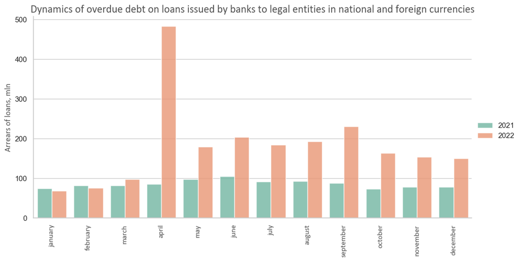

```python
sns.set(context='notebook', style='whitegrid', palette='Set2', font='sans-serif', font_scale=1, color_codes=False, rc=None)
# sns.set_theme(style="darkgrid")

g = sns.catplot(data=pivot_table, kind="bar", x="month", y="arrears", hue="Years", alpha=0.8, aspect=2)

g.set_axis_labels("", "Arrears of loans, mln", color=font_color, **hfont)
g.legend.set_title("")
plt.title('Dynamics of overdue debt on loans issued by banks to legal entities in national and foreign currencies', fontsize= 16, color=font_color, **hfont)

plt.xticks(rotation=90, color=font_color, **hfont)
plt.show()
```

The total overdue debt in 2022 since April has increased by about 2 times compared to 2021.  
A multiple peak was observed in April, by 393% from March.

- **Visualization of arrears on loans as a percentage of the total loan amount**

```python
pivot_table = pivot_table.assign(per_arrears=pivot_table.arrears/pivot_table.EQ*100)
pivot_table['per_arrears'] = pivot_table.per_arrears.apply(lambda x: round(x, 2))
```

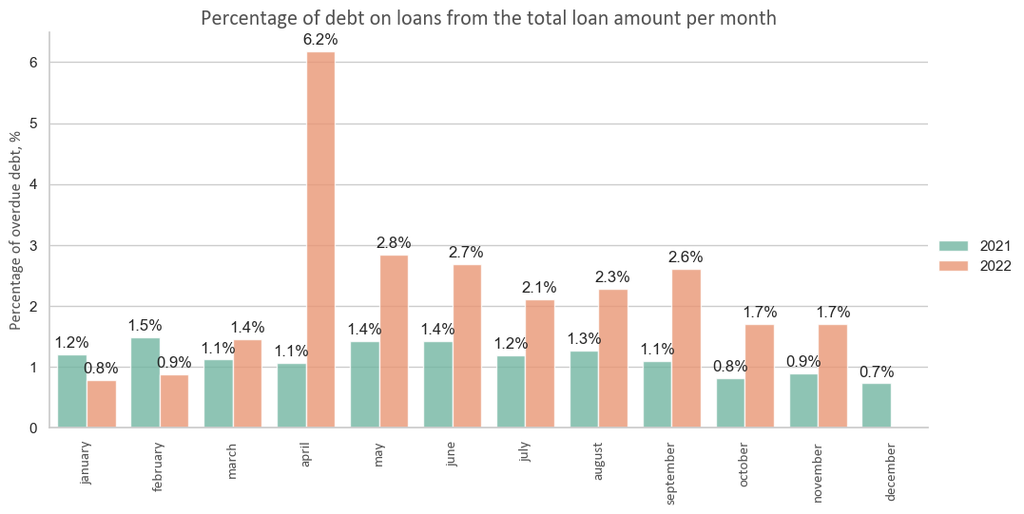

```python
p = sns.catplot(data=pivot_table, kind="bar", x="month", y="per_arrears", hue="Years", palette='Set2', alpha=0.8, aspect=2)

p.set_axis_labels("", "Percentage of overdue debt, %", color=font_color, **hfont)
p.legend.set_title("")
plt.title('Percentage of debt on loans from the total loan amount per month', fontsize= 16, color=font_color, **hfont)

plt.xticks(rotation=90, color=font_color, **hfont)

ax = plt.gca()
autolabel_3(ax.patches, '.1f')

plt.show()
```

Abnormally large jump in arrears of loans in April 2022.  
This may be due to the large volume of lending in RUB in March 2022.  
Then the situation began to level off, despite even more lending in RUB in April (peak value 6.2%)

**3.4 |** Analysis of average interest rates on new loans issued by banks

- **Lending rates by type of currency per month**

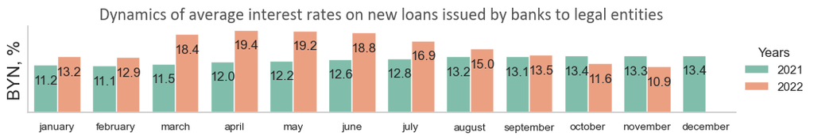

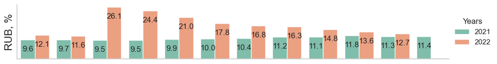

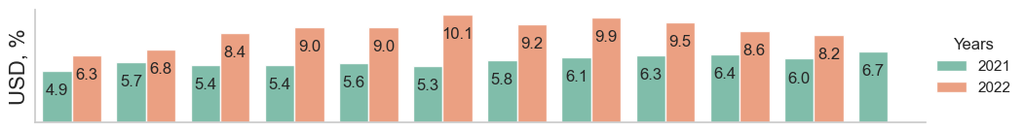

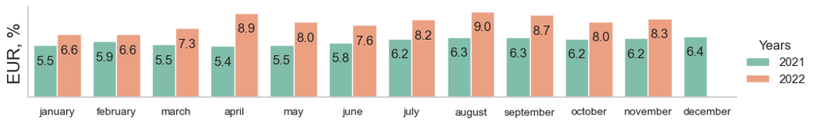

```python
def autolabel_5(rects, fmt='.2f'):
    # attach some text labels
    for rect in rects:
        height = rect.get_height()
        rect.axes.annotate(f'{{:{fmt}}}'.format(height),
                           xy=(rect.get_x()+rect.get_width()/2., height),
                           xytext=(0, -20), textcoords='offset points',
                           ha='center', va='bottom')

ax_1 = sns.catplot(x="month", y="per_BYN", hue="Years", data=pivot_table, kind="bar", alpha=0.9, height=2, aspect=5)

plt.title('Dynamics of average interest rates on new loans issued by banks to legal entities', fontsize= 16, color=font_color, **hfont)
ax_1.set_axis_labels("", "BYN, %", fontsize= 16)

ax_1 = plt.gca()
autolabel_5(ax_1.patches, '.1f')
ax_1.set_yticks([])
ax_1.xaxis.set_tick_params(rotation=0, labelsize=10)

ax_2 = sns.catplot(x="month", y="per_RUB", hue="Years", data=pivot_table, kind="bar", alpha=0.9, height=2, aspect=5)
# plt.title('Dynamics of average interest rates on new loans issued by banks to legal entities in the RUB', fontsize= 16 )
ax_2.set_axis_labels("", "RUB, %", fontsize= 16)
ax_2 = plt.gca()
ax_2.xaxis.set_tick_params(rotation=0, labelsize=10)
autolabel_5(ax_2.patches, '.1f')
ax_2.set_yticks([])
ax_2.set_xticks([])

ax_3 = sns.catplot(x="month", y="per_USD", hue="Years", data=pivot_table, kind="bar", alpha=0.9, height=2, aspect=5)
# plt.title('Dynamics of average interest rates on new loans issued by banks to legal entities in the USD', fontsize= 16 )
ax_3.set_axis_labels("", "USD, %", fontsize= 16)
ax_3 = plt.gca()
ax_3.xaxis.set_tick_params(rotation=0, labelsize=10)
autolabel_5(ax_3.patches, '.1f')
ax_3.set_yticks([])
ax_3.set_xticks([])

ax_4 = sns.catplot(x="month", y="per_EUR", hue="Years", data=pivot_table, kind="bar", alpha=0.9, height=2, aspect=5)
# plt.title('Dynamics of average interest rates on new loans issued by banks to legal entities in the EUR', fontsize= 16 )
ax_4.set_axis_labels("", "EUR, %", fontsize= 16)
ax_4 = plt.gca()
ax_4.xaxis.set_tick_params(rotation=0, labelsize=10)
autolabel_5(ax_4.patches, '.1f')
ax_4.set_yticks([])

plt.show()
```

In 2021, interest rates rose slightly across all currencies.  
In 2022, interest rates rose sharply in March and April in BYN and RUB, and since May, the percentage has been gradually decreasing. In USD and EUR in March and April, interest rates increased from 6.5 to 8-9% per annum.

- **The amount of the loan issued relative to the value of the interest**

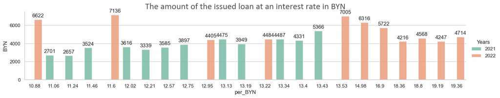

```python
sns.catplot(x="per_BYN", y="BYN", hue="Years", data=pivot_table, ci=100,
                kind="bar", alpha=0.8, aspect=5, height=3)
plt.title('The amount of the issued loan at an interest rate in BYN', fontsize= 20, color=font_color, **hfont)
ax = plt.gca()
autolabel_1(ax.patches, '.0f')
```

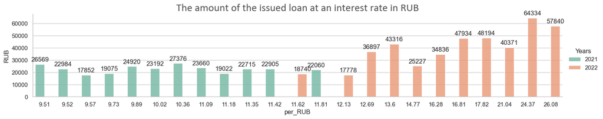

```python
sns.catplot(x="per_RUB", y="RUB", hue="Years", data=pivot_table, ci=200,
                kind="bar", alpha=0.8, aspect=5, height=3)
plt.title('The amount of the issued loan at an interest rate in RUB', fontsize= 20, color=font_color, **hfont)
ax = plt.gca()
autolabel_1(ax.patches, '.0f')
```

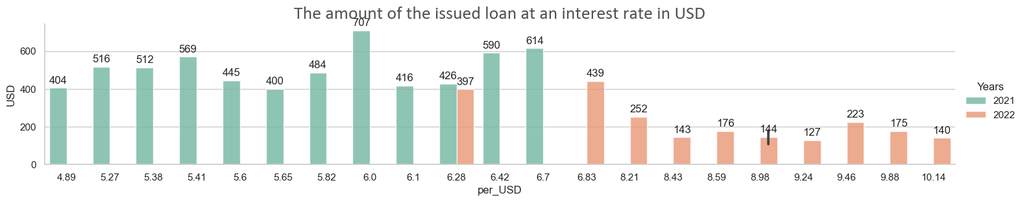

```python
sns.catplot(x="per_USD", y="USD", hue="Years", data=pivot_table, ci=100,
                kind="bar", alpha=0.8, aspect=5, height=3)
plt.title('The amount of the issued loan at an interest rate in USD', fontsize= 20, color=font_color, **hfont)
ax = plt.gca()
autolabel_1(ax.patches, '.0f')
```

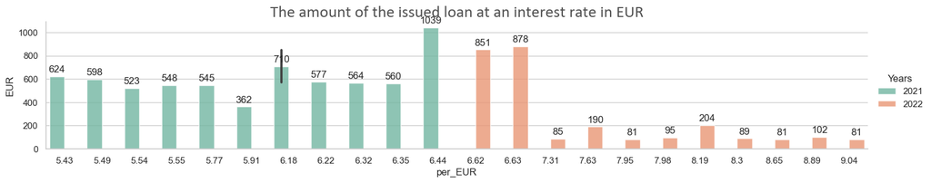

```python
sns.catplot(x="per_EUR", y="EUR", hue="Years", data=pivot_table, ci=100,
                kind="bar", alpha=0.8, aspect=5, height=3)
plt.title('The amount of the issued loan at an interest rate in EUR', fontsize= 20, color=font_color, **hfont)
ax = plt.gca()
autolabel_1(ax.patches, '.0f')
```

**Let's look at the relationship between loan amounts and interest rates:**  
There is a dependence, the more lending, the higher the interest rate.  
But this is not the main correlation. Obviously, the increase in interest rates is more a reaction to inflationary expectations.  
From the abnormal, one can notice low interest rates in BYN in October (11.6) and November (10.9) 2022 with large high lending.

**3.5 |** Study of the amounts of loans issued reduced to the single currency (BYN)

- **Loading a table with exchange rates**

```python
kurs = pd.read_excel("d:\TableauData\Data_upiter\kurs_2021_2022.xlsx")
```

- **Adding converted data (currency*rate)**
- **Joining tables**

```python
pivot_table = pivot_table.merge(kurs, on=['Years', 'month'])
pivot_table.k_RUB = pivot_table.k_RUB/100
```

```python
pivot_table['RUB_eq']=round(pivot_table['k_RUB']*pivot_table['RUB'], 1)
pivot_table['USD_eq']=round(pivot_table['k_USD']*pivot_table['USD'], 1)
pivot_table['EUR_eq']=round(pivot_table['k_EUR']*pivot_table['EUR'], 1)
```

```python
pivot_table.tail(2)
```

|  | Years | month | BYN | RUB | USD | EUR | EQ | arrears | per_BYN | per_RUB | per_USD | per_EUR | per_arrears | k_RUB | k_USD | k_EUR | RUB_eq | USD_eq | EUR_eq |
| --- | --- | --- | --- | --- | --- | --- | --- | --- | --- | --- | --- | --- | --- | --- | --- | --- | --- | --- | --- |
| 22 | 2021 | december | 5366.3 | 22904.7 | 613.8 | 1038.7 | 10677.1 | 77.9 | 13.43 | 11.42 | 6.7 | 6.44 | 0.73 | 0.034328 | 2.5315 | 2.861 | 786.3 | 1553.8 | 2971.7 |
| 23 | 2022 | december | NaN | NaN | NaN | NaN | NaN | 150.1 | NaN | NaN | NaN | NaN | NaN | NaN | NaN | NaN | NaN | NaN | NaN |

- **Creating a Total_Table and Checking Variance**

```python
total = pivot_table.groupby('Years').agg('sum')[['BYN', 'RUB_eq', 'USD_eq', 'EUR_eq', 'EQ']] \
                    .assign(total_eq=lambda x: x['BYN']+x['RUB_eq']+x['USD_eq']+x['EUR_eq']) \
                    .rename(columns=lambda col: col.replace('_eq', ''))

total
```

| Years | BYN | RUB | USD | EUR | EQ | total |
| --- | --- | --- | --- | --- | --- | --- |
| 2021 | 45926.3 | 9384.0 | 15424.0 | 21975.6 | 92713.0 | 92709.9 |
| 2022 | 59437.2 | 17017.3 | 6165.6 | 7831.3 | 90568.9 | 90451.4 |

[EQ] != [total]

But the discrepancy is not significant

The reason for the discrepancy is that the exchange rates were formed manually

- **Visualization of the ratio of the volumes of loans issued in the national currency**

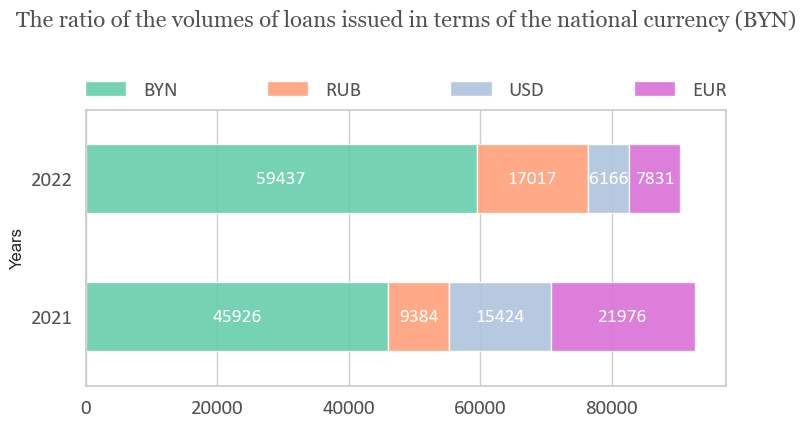

```python
t = total[['BYN', 'RUB', 'USD', 'EUR']]

font_color = '#525252'
csfont = {'fontname':'Georgia'} # title font
hfont = {'fontname':'Calibri'} # main font
colors = ['#66CDAA', '#FFA07A', '#B0C4DE', '#DA70D6']

ax = t.plot.barh(align='center', stacked=True, figsize=(10, 4), color=colors, alpha=0.9)
ax.grid(axis='y')
# plt.tight_layout()

title = plt.title('The ratio of the volumes of loans issued in terms of the national currency (BYN)', pad=60, fontsize=16, color=font_color, **csfont)
title.set_position([.5, 1.02])

# Adjust the subplot so that the title would fit
plt.subplots_adjust(top=0.8, left=0.26)

# Set labels’ and ticks’ font size and color
for label in (ax.get_xticklabels() + ax.get_yticklabels()):
    label.set_fontsize(15)
plt.xticks(color=font_color, **hfont)
plt.yticks(color=font_color, **hfont)

# Create a legend
legend = plt.legend(loc='center',
       frameon=False,
       bbox_to_anchor=(0., 1.02, 1., .102),
       mode='expand',
       ncol=4,
       borderaxespad=-.46,
       prop={'size': 15, 'family':'Calibri'})

for text in legend.get_texts():
    plt.setp(text, color=font_color) # legend font color

# Create annotations
for p in ax.patches:
    width, height = p.get_width(), p.get_height()
    x, y = p.get_xy()
    ax.text(x+width/2,
            y+height/2,
            '{:.0f}'.format(width),
            horizontalalignment='center',
            verticalalignment='center',
            color='white',
            fontsize=14,
            **hfont)
# plt.show()
# filename = 'barh_plot-stacked'
# plt.savefig(filename+'.png')
```

**There is a noticeable difference in the currency of lending.**

- In 2021, there was a large amount of lending in EUR and USD
- In 2022, lending was redistributed to RUB
- **Percentage of issued loans converted into BYN**

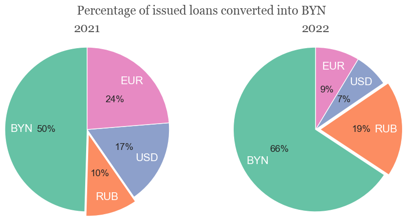

```python
t_2021 = t.query('Years == 2021').reset_index()[['BYN', 'RUB', 'USD', 'EUR']]
t_2022 = t.query('Years == 2022').reset_index()[['BYN', 'RUB', 'USD', 'EUR']]

fig, (ax_1, ax_2) = plt.subplots(1, 2)
plt.subplots_adjust(wspace=1, hspace=1, left=0, right=1.1)
ti = fig.suptitle('Percentage of issued loans converted into BYN', fontsize=18, color=font_color, **csfont)
ti.set_position([0.55, 1.03])

# Pie ---2021----
labels = t_2021.columns
x_1 = t_2021.iloc[0]

patches, texts, autotexts = ax_1.pie(radius=1.8, x=x_1, labels=labels, autopct='%1.0f%%',
    colors=sns.color_palette('Set2'),
    labeldistance=0.8,
    pctdistance=0.5,
    startangle=90,
    normalize=True,
    explode=[0, 0.1, 0, 0])


ax_1.set_title('2021', pad=60, fontsize=18, color=font_color, **csfont)

# Customize text labels
for text in texts:
    text.set_horizontalalignment('center')
    text.set_fontsize(16)
    text.set_color('white')

# Customize percent labels
for autotext in autotexts:
    autotext.set_horizontalalignment('center')
    autotext.set_fontstyle('normal')
    autotext.set_fontsize(14)

# Pie ---2022----
x_2 = t_2022.iloc[0]

patches, texts, autotexts = ax_2.pie(radius=1.8,
    x=x_2,
    labels=labels,
    autopct='%1.0f%%',
    colors=sns.color_palette('Set2'),
    labeldistance=0.8,
    pctdistance=0.5,
    startangle=90,
    explode=[0, 0.1, 0, 0])

ax_2.set_title('2022', pad=60, fontsize=18, color=font_color, **csfont)

# Customize text labels
for text in texts:
    text.set_horizontalalignment('center')
    text.set_fontsize(16)
    text.set_color('white')

# Customize percent labels
for autotext in autotexts:
    autotext.set_horizontalalignment('center')
    autotext.set_fontstyle('normal')
    autotext.set_fontsize(14)
```

**In percentage terms, in 2022 there was a noticeable increase in the share of lending in RUB and BYN**

# **4 | Visualization and data analysis of issued loans by types of activity**

**4.1 |** Creating separate tables

- **Formatting a pivot table into tables for individual currencies**

```python
# df_types.columns.to_list()
```

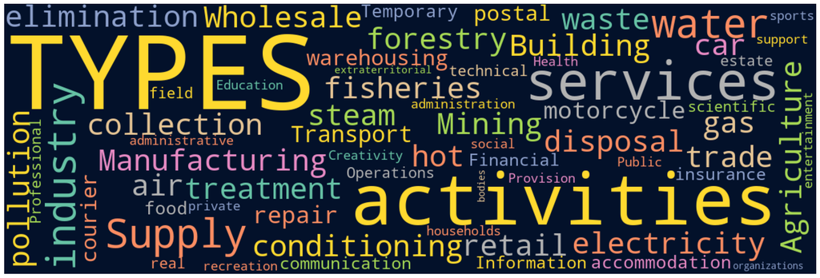

```python
# Word cloud based on Indicators
text = " TYPES ".join(w for w in df_types['Indicators'])
stop_words = list(STOPWORDS)
wordcloud = WordCloud(width=1200, height=400, stopwords=stop_words, background_color='#03112A', colormap='Set2', collocations=False, random_state=2023).generate(text)
plt.figure(figsize=(25,20))
plt.imshow(wordcloud)
plt.axis("off")
plt.show()
```

```python
'''  Creating a dictionary of future table names and slicing index '''

dict_future_tables_types = {'Name of dataframe': 'start_index', 'df_types_loans_issued_BYN': 4, 'df_types_loans_issued_USD': 16,
                             'df_types_loans_issued_EUR': 28, 'df_types_loans_issued_RUB': 40,
                             'df_types_loans_issued_EQ': 52, 'df_types_debt_on_loans': 64,  'df_types_percent_BYN': 76,
                             'df_types_percent_USD': 88, 'df_types_percent_EUR': 100, 'df_types_percent_RUB': 112}
dict_future_tables_types
```

```
{'Name of dataframe': 'start_index',
 'df_types_loans_issued_BYN': 4,
 'df_types_loans_issued_USD': 16,
 'df_types_loans_issued_EUR': 28,
 'df_types_loans_issued_RUB': 40,
 'df_types_loans_issued_EQ': 52,
 'df_types_debt_on_loans': 64,
 'df_types_percent_BYN': 76,
 'df_types_percent_USD': 88,
 'df_types_percent_EUR': 100,
 'df_types_percent_RUB': 112}
```

```python
df_types_loans_issued_BYN = cut_table(df_types, 4)
df_types_loans_issued_USD = cut_table(df_types, 16)
df_types_loans_issued_EUR = cut_table(df_types, 28)
df_types_loans_issued_RUB = cut_table(df_types, 40)
df_types_loans_issued_EQ = cut_table(df_types, 52)
df_types_debt_on_loans = cut_table(df_types, 64)
df_types_percent_BYN = cut_table(df_types, 76)
df_types_percent_USD = cut_table(df_types, 88)
df_types_percent_EUR = cut_table(df_types, 100)
df_types_percent_RUB = cut_table(df_types, 112)
```

```python
# Replacing NaN with previous values (November 2022). Because December 2022 values are not known
types_BYN = df_types_loans_issued_BYN.fillna(method='pad', axis=1)
types_USD = df_types_loans_issued_USD.fillna(method='pad', axis=1)
types_EUR = df_types_loans_issued_EUR.fillna(method='pad', axis=1)
types_RUB = df_types_loans_issued_RUB.fillna(method='pad', axis=1)
types_EQ = df_types_loans_issued_EQ.fillna(method='pad', axis=1)
```

**4.2 |** Analysis of data on loans issued for the year by type

- **Visualization of the volume of loans issued to legal entities in national and foreign currencies per year**

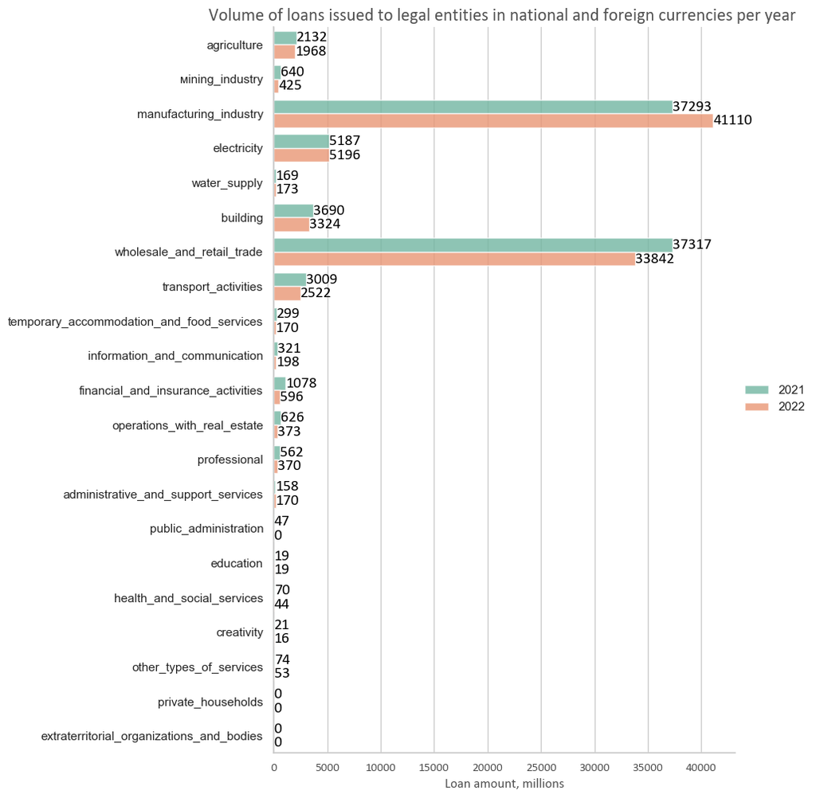

```python
def autolabel_4(rects):
    for r in rects:
        width, height = r.get_width(), r.get_height()
        x, y = r.get_xy()
        ax.text(width,
                y+height/2,
                '{:.0f}'.format(width),
                horizontalalignment='left',
                verticalalignment='center',
                color='black',
                fontsize=14,
                **hfont)

g = sns.catplot(data=types_EQ, kind="bar", x="Total_december", y="indicators_id", hue="Years", alpha=0.8, height=10, aspect=1)

g.set_axis_labels("Loan amount, millions", "", color=font_color, **hfont)
g.legend.set_title("")
plt.title('Volume of loans issued to legal entities in national and foreign currencies per year ', fontsize= 16, color=font_color, **hfont)

plt.xticks(rotation=0, color=font_color, **hfont)

# Create annotations
ax = plt.gca()
autolabel_4(ax.patches)

plt.show()
```

In general, it can be seen that in 2022 loans were issued less than in 2021. With the exception of **Manufacturing industry**.

The top five are in order:

- *Manufacturing industry*
- *Wholesale and retail trade; car and motorcycle repair*
- *Supply of electricity, gas, steam, hot water and air conditioning*
- *Building*
- *Transport activities, warehousing, postal and courier activities*

Moreover, the difference between the second in the list and the third is 6.5 times! Closes with noticeable volumes of loans issued - *Agriculture, forestry and fisheries*

- **Visualization of the volume of loans issued to legal entities in BYN per year**

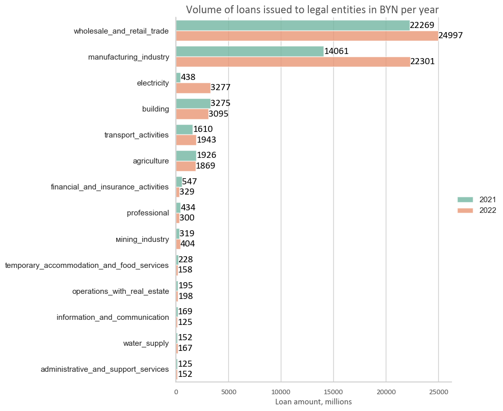

```python
g = sns.catplot(data=types_BYN.iloc[0:28].sort_values(by='BYN_january-december', ascending=False), kind="bar",
                x="BYN_january-december", y="indicators_id", hue="Years", alpha=0.8, height=8, aspect=1.2)

g.set_axis_labels("Loan amount, millions", "", color=font_color, **hfont)
g.legend.set_title("")
plt.title('Volume of loans issued to legal entities in BYN per year ', fontsize= 16, color=font_color, **hfont)

plt.xticks(rotation=0, color=font_color, **hfont)

# Create annotations
ax = plt.gca()
autolabel_4(ax.patches)
```

The share of issued loans increased in BYN.  
In 2022, a 7.5 times increase in **Supply of electricity, gas, steam, hot water and air conditioning.**  
There is also a noticeable increase in the **Manufacturing industry.**

- **Visualization of the volume of loans issued to legal entities in USD per year**

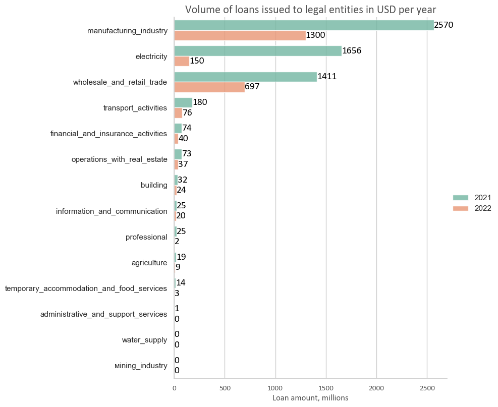

```python
g = sns.catplot(data=types_USD.iloc[0:28].sort_values(by='USD_january-december', ascending=False), kind="bar",
                x="USD_january-december", y="indicators_id", hue="Years", alpha=0.8, height=8, aspect=1.2)

g.set_axis_labels("Loan amount, millions", "", color=font_color, **hfont)
g.legend.set_title("")
plt.title('Volume of loans issued to legal entities in USD per year', fontsize= 16, color=font_color, **hfont)

plt.xticks(rotation=0, color=font_color, **hfont)

# Create annotations
ax = plt.gca()
autolabel_4(ax.patches)
```

In USD, the volume of loans issued fell significantly.  
In the field of **Supply of electricity, gas, steam, hot water and air conditioning**, the fall occurred 11 times!  
For other industries, the decline was approximately 2 times.

- **Visualization of the volume of loans issued to legal entities in EUR per year**

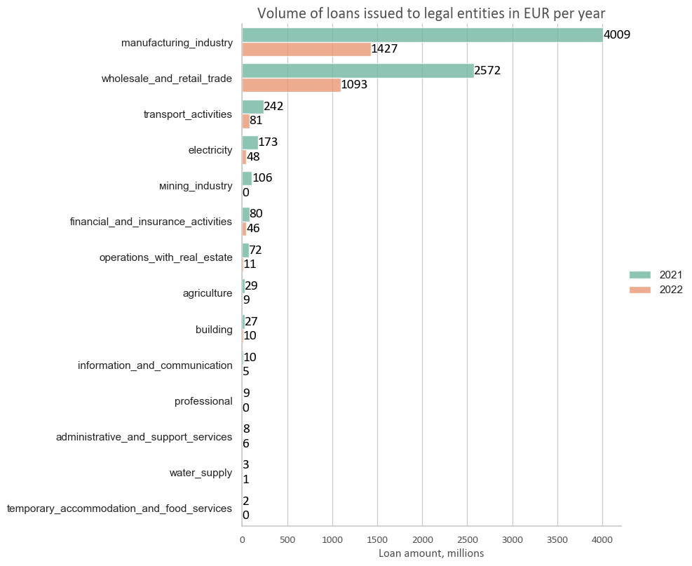

```python
g = sns.catplot(data=types_EUR.iloc[0:28].sort_values(by='EUR_january-december', ascending=False), kind="bar",
                x="EUR_january-december", y="indicators_id", hue="Years", alpha=0.8, height=8, aspect=1.2)

g.set_axis_labels("Loan amount, millions", "", color=font_color, **hfont)
g.legend.set_title("")
plt.title('Volume of loans issued to legal entities in EUR per year', fontsize= 16, color=font_color, **hfont)

plt.xticks(rotation=0, color=font_color, **hfont)

# Create annotations
ax = plt.gca()
autolabel_4(ax.patches)
```

- **Visualization of the volume of loans issued to legal entities in RUB per year**

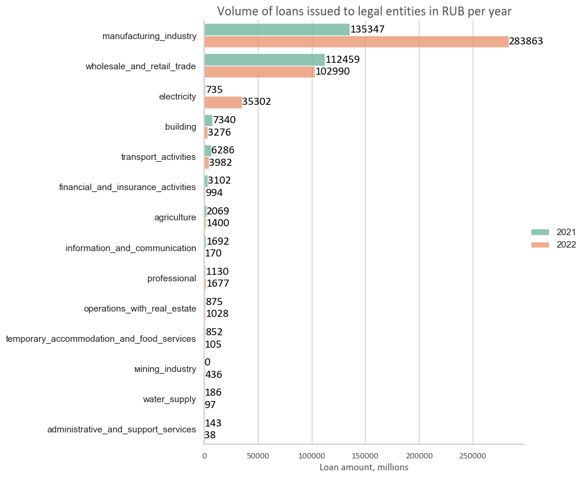

```python
g = sns.catplot(data=types_RUB.iloc[0:28].sort_values(by='RUB_january-december', ascending=False), kind="bar",
                x="RUB_january-december", y="indicators_id", hue="Years", alpha=0.8, height=8, aspect=1.2)

g.set_axis_labels("Loan amount, millions", "", color=font_color, **hfont)
g.legend.set_title("")
plt.title('Volume of loans issued to legal entities in RUB per year', fontsize= 16, color=font_color, **hfont)

plt.xticks(rotation=0, color=font_color, **hfont)

# Create annotations
ax = plt.gca()
autolabel_4(ax.patches)
```

Replacing the volumes of lending in USD and EUR, there was an increase in RUB in some areas of activity.

```python
# df_types.to_excel('./types_pivot_tableau.xlsx')
```

```python
# pivot_table.to_excel('./total_pivot_tableau.xlsx')
```

# **5 | General conclusions**

- **Calculate the percentage of loans between years**

```python
total.loc['how much in 2021 more than in 2022']=((total.iloc[0] - total.iloc[1])/total.iloc[1]).apply(lambda x: "{:.0%}".format(x))
total.loc['how much in 2022 more than in 2021']=((total.iloc[1] - total.iloc[0])/total.iloc[0]).apply(lambda x: "{:.0%}".format(x))
total.drop('total', axis=1).rename(columns={'EQ': 'TOTAL'})
```

| Years | BYN | RUB | USD | EUR | TOTAL |
| --- | --- | --- | --- | --- | --- |
| 2021 | 45926.3 | 9384.0 | 15424.0 | 21975.6 | 92713.0 |
| 2022 | 59437.2 | 17017.3 | 6165.6 | 7831.3 | 90568.9 |
| how much in 2021 more than in 2022 | -23% | -45% | 150% | 181% | 2% |
| how much in 2022 more than in 2021 | 29% | 81% | -60% | -64% | -2% |

**In general, the amount of loans issued to legal entities for 11 months of 2022 is at the level of 12 months of 2021. However, the lending currency has changed a lot.**

1. In 2021, loans reduced to the national currency (BYN) were issued:

- in USD, 150% more than in 2022;
- in EUR, 181% more than in 2022

2. In 2022, loans reduced to the national currency (BYN) were issued:

- in BYN, 29% more than in 2021;
- in RUB, 81% more than in 2021;
- in USD, 60% less than in 2021;
- in EUR, 64% less than in 2021

3. The lending structure changed dramatically in March-April 2022. The changes are related to the start of a special military operation in Ukraine on 02/24/2022

4. Interest rates on loans were raised to stabilize the financial market and reacted to the shock. However, in the subsequent interest rates on loans went down. However, they did not reach the low values they were in 2021. There were exceptions for BYN since October 2022, when interest rates on loans dropped to 2021 levels

5. Overdue debt reached its maximum in April 2022 and amounted to 6.2% of the total loan. In general, arrears on loans, starting from May 2022, gradually decreased to 1.7%. At the same time, in 2021, overdue debt was in the range of 0.7 - 1.5%

6. By type of activity in 2022, the volume of loans issued was less than in 2021. With the exception of the manufacturing industry, due to which there was an increase in lending. Some areas of the economy have ceased to be credited

7. In the context of currencies, a transition from USD and EUR to RUB is visible. And also the share in BYN was increased. This is especially noticeable in **Supply of electricity, gas, steam, hot water and air conditioning, Manufacturing industry** and **Wholesale and retail trade**. Perhaps this is due to a decrease in the volume of trade with European countries, an increase in the supply of goods to the Russian Federation and the transition of payments for energy carriers (gas) to RUB

___________________________________________________________________________

All the above changes in the structure of lending to legal entities are the consequences of the military operation in Ukraine